# How a Nation’s Corruption Impacts the Happiness of Their People

Authors

Jack Colt

Finn Balfe

John Brune

Alex Musco

```r
library(tidyverse)
library(janitor)
library(gganimate)
library(glue)
library(kableExtra)
library(purrr)
corruption <- read.csv("corruption_perception_index.csv")
happiness <- read.csv("hapiscore.csv")
```

# Project Proposal + Data

## Data and Variable Description

To analyze the association between a country’s Corruption Perception Index (CPI) and World Happiness Report (WHR) we are using data obtained from Gapminder, a Swedish website that collects time series data from multiple sources to create unique datasets that cannot be found elsewhere. We are collecting data from Gapminder for both of our variables, with individual countries as the observational unit.

Our explanatory variable is the Corruption Perception Index, which is an index that is published annually by the non-government organization, *Transparency International*. The index ranks 180 countries on a scale of 0 (highly corrupt) to 100 (very clean) based on how corrupt their governments are each year. It is optimal for a country to have the highest score possible because that would indicate less corruption in their government.

Our response variable is a Happiness Score from the World Happiness Report, a partnership of Gallup, the Oxford Wellbeing Research Centre, the UN Sustainable Development Solutions Network, and the WHR’s Editorial Board, under which the report is published. Each observation is the national average response of life evaluations, which are measured by asking individuals to rate their current lives on a scale of 0 to 10 (with 10 meaning the individual has a perfect life) – a question called the “Cantril Ladder.” Gapminder converted the observations to a scale of 0 to 100, which works well with our explanatory variable (CPI) as they are on the same scales in our datasets.

## Hypothesized Relationship Between Our Variables

We expect a positive relationship between Corruption Score and Happiness Score because we believe that countries with high corruption scores (meaning the country has low corruption) would experience more happiness overall. If a nation’s government is suspected to be corrupt, we hypothesize that it is more likely for their citizens to experience lower rates of happiness, since their government is ineffective. Corruption usually leads to a lower quality of life, since the economy is overall damaged and ran inefficiently by the government’s misconduct, leading to lower potential output in the economic long run and lower living standards for its citizens. According to Elvin Mirzayev, a writer for *Investopedia*, corrupt economic operations often “lead to monopolies or oligopolies in the economy.” Monopolies are objectively harmful to buyers in the economy, and lead to high prices and lower quality products for consumers. Overall, we would expect a nation with high corruption (a low CPI) to have a low WHR score, while a nation with low corruption (high CPI) would experience higher WHR scores.

## Data Cleaning

```r
corruption <- corruption |>
  clean_names() |>
  pivot_longer(cols = c(x2012, x2013, x2014, x2015, x2016, x2017),
               names_to = "year",
               values_to = "corruption") |>
  filter(!(is.na(corruption)))
```

For our corruption data, we first used the janitor package to get our column names in tidy form. Next, we pivot longer the years from 2012 to 2017 because those are the only years we have corruption data for. Then, we remove any observations that contain missing values in the new corruption column. We chose to remove missing values after pivoting because, for countries that are only missing data for some of the years, we want to keep the data for the years we have data for.

```r
happiness <- happiness |>
  clean_names() |>
  select(country, x2012, x2013, x2014, x2015, x2016, x2017) |>
  pivot_longer(cols = c(x2012, x2013, x2014, x2015, x2016, x2017),
               names_to = "year",
               values_to = "happiness") |>
  filter(!(is.na(happiness)))
```

For our happiness data, we first use the janitor package to get the column names in tidy form. Next, we select the country column and the years 2012 to 2017 because we only have corruption data for those years. Then, we pivot longer those years and remove observations that contain missing values in our new happiness columns for the same reason as the corruption data.

```r
data <- happiness |>
  inner_join(corruption,
             join_by(country, year)) |>
  mutate(country = fct(country),
         year = fct(substr(year, 2, 5)))
```

Finally, we inner join the happiness and corruption datasets on country name and year. We chose an inner join to remove country, year pairs that we do not have both happiness and corruption scores for. Lastly, we factor the country and year columns and remove the ‘x’ prefix from the year values.

# Linear Regression

## Data Visualization

To analyze the relationship between a country’s average happiness score and their CPI score, we will first visualize the variables’ relationship through a scatter plot with a fitted linear regression line.

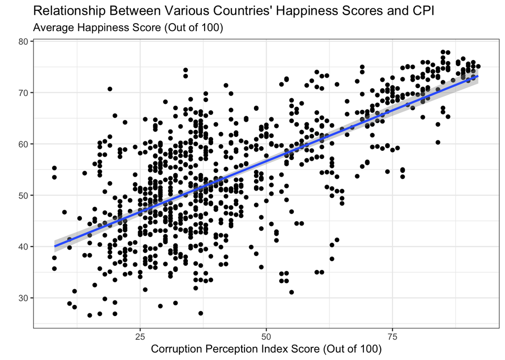

```r
hs_vs_cpi_plot <- ggplot(data = data,
       mapping = aes(x = corruption,
                     y = happiness)) +
  geom_point() +
  geom_smooth(method = "lm") +
  labs(title = "Relationship Between Various Countries' Happiness Scores and CPI",
       subtitle = "Average Happiness Score (Out of 100)",
       y = "",
       x = "Corruption Perception Index Score (Out of 100)") +
  theme_bw()

hs_vs_cpi_plot
```

The above plot displays our response variable, a country’s happiness score, on the y-axis and our explanatory variable, a country’s CPI score, on the x-axis and plots the observed values of each country between the years 2012 and 2017. From the plot, we can observe a moderately strong, positive, and linear relationship between the two variables, which aligns with our hypothesis. As a country’s CPI score increases (meaning they have less corruption in their government) the nation’s average happiness also increases and vice-versa.

Although it is useful to visualize the trend in our variables over all the years in our data (2012 - 2017), we also want to visualize how their relationship has changed over time. We will do this in the animated plot below.

```r
animated_plot <- ggplot(data, aes(x = corruption,
                                  y = happiness)) +
  geom_point(aes(color = year)) +
  geom_smooth(method = "lm", aes(color = year)) +
  labs(title = "Relationship Between Various Country's Happiness Scores and CPI",
       subtitle = "Average Happiness Score (Out of 100)",
       y = "",
       x = "Corruption Perception Index Score (Out of 100)") +
  theme_bw() +
  transition_states(year,
                    transition_length = 2,
                    state_length = 3) +
  ggtitle("Various Countries' Happiness Scores vs CPI in {closest_state}")

animate(
  animated_plot + enter_fade() + exit_fly(y_loc = 1),
  renderer = av_renderer())
```

[video not shown]

From the animation above, we can observe that the relationship between various countries’ average happiness scores versus their level of corruption has not changed much between 2012 and 2017, as many of the associations seem to be very similar. This gives us confidence that the association between our two variables tends to be relatively constant over time.

## Linear Regression

We will now conduct a statistical method known as *Linear Regression* to assess the association between a country’s average happiness score and their CPI score. Linear regression is a statistical method used to model and analyze the relationship between a response variable (in our case, average happiness score) and one or more explanatory variables. The goal is to fit a linear equation to the observed data, where the equation predicts the response variable based on the values of the explanatory variables. The simplest form, *simple linear regression*, involves one response and one explanatory variable (which in our case will be CPI score), and finds the best-fitting straight line in equation form $y = mx + b$ that minimizes the sum of the squared differences between observed and predicted values.

To perform linear regression, we want to have only one x-value and one y-value for each of our countries. To do this, we will take the mean value for both average happiness score and CPI score for each country across all the years in our dataset (2012-2017). We chose this method of obtaining one x and y value for each of our countries because we felt it was the method that most represented all the observations in the full dataset, especially because there was not much change in the relationship between our variables over the years as observed in the animated plot in the last section.

Below is a new plot visualizing the relationship between average happiness score and average CPI score for each country across the years 2012 through 2017. This will be the data we use in fitting our linear regression model.

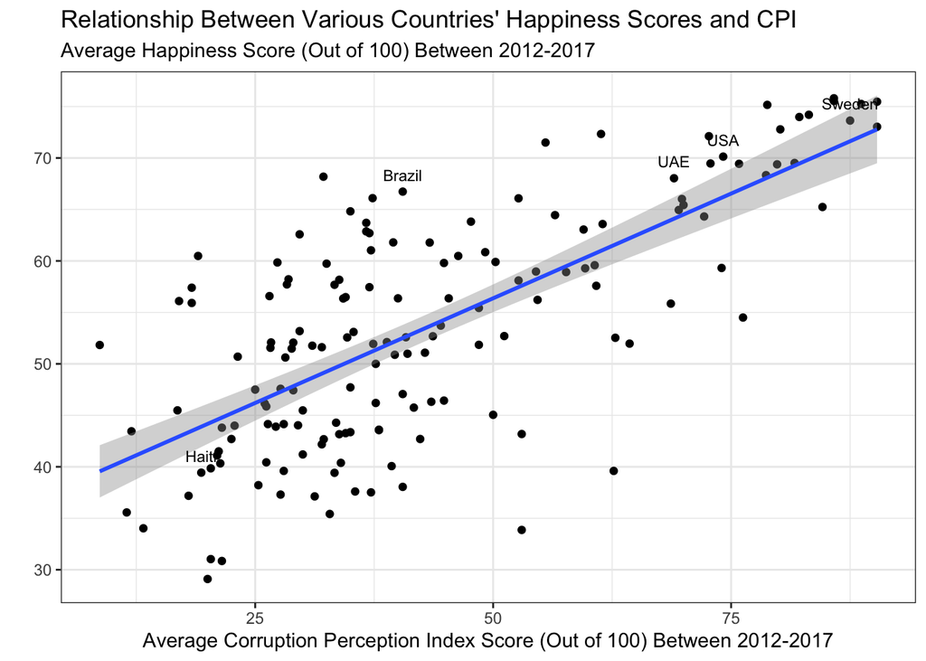

```r
data_by_country <- data |>
  group_by(country) |>
  summarise(happiness = mean(happiness),
            corruption = mean(corruption))

ggplot(data = data_by_country,
       mapping = aes(x = corruption,
                     y = happiness)) +
  geom_point() +
  geom_smooth(method = "lm") +
  labs(title =
         "Relationship Between Various Countries' Happiness Scores and CPI",
       subtitle = "Average Happiness Score (Out of 100) Between 2012-2017",
       y = "",
       x = "Average Corruption Perception Index Score (Out of 100) Between 2012-2017") +
  theme_bw() +
  geom_text(data = subset(data_by_country, country %in% c("USA", "Sweden", "Haiti", "UAE",
                                                          "Brazil")),
            aes(label = country),
            vjust = -1, size = 3, check_overlap = TRUE)
```

Now that we have visualized our new dataset with one observation per country, we will use it to fit our linear model.

```r
data_lm <- lm(happiness ~ corruption,
              data = data_by_country)
summary(data_lm)
```

[output not shown]

After fitting a simple linear model between the average happiness score across the years 2012 through 2017 for each country versus the average CPI score across the years 2012 through 2017 for each country in our dataset, we have obtained our estimated regression equation below:

$$\hat{y} = 0.407x + 36.032$$

**Interpreting Our Coefficients**

According to the fitted linear model above, for every one point increase in the CPI score for a country, the country’s mean increase in average happiness score will be about 0.407 points. Furthermore, if a country’s CPI score is 0, meaning they are extremely corrupt, their mean happiness score will be about 36.032 on average, which is a relatively low happiness score. Our intercept does make sense in this context, as it is technically possible for a country to have a CPI score of 0.

## Model Fit

Below is a table displaying the total variance of the response values in our fitted model, and how much of the variance is explained by both our fitted values and our residuals.

```r
response_variance <- var(data_by_country$happiness)
fitted_values <- predict(data_lm)
fitted_variance <- var(fitted_values)
residuals <- residuals(data_lm)
residual_variance <- var(residuals)

variance_table <- data.frame(
  Metric = c("Variance in Response Values", "Variance in Fitted Values", "Variance in Residuals"),
  Variance = c(response_variance, fitted_variance, residual_variance))

variance_table |>
  kable() |>
  kable_styling(bootstrap_options = c("striped", "hover", "condensed"))
```

| Metric | Variance |
| --- | --- |
| Variance in Response Values | 129.14239 |
| Variance in Fitted Values | 65.42916 |
| Variance in Residuals | 63.71323 |

**Interpreting the variability**

From the regression summary, the $R^2$ value is approximately 0.5066, which means that 50.66% of the variability in a nation’s average happiness score is explained by their CPI score. This moderate $R^2$ value indicates that while CPI is an important factor in predicting happiness score, other variables such as social, economic, or political influences likely play a significant role as well. The table of variances is in agreement with our $R^2$ value, showing that about half of the variability is left unexplained by the fitted values, illustrating that the remaining variance is explained by the residuals and points to the influence of factors not included in our model, suggesting a moderate model fit. Some of the variance in the residuals may be explained by factors such as political freedoms and standards of living, but these extrapolations are outside the scope of this research paper.

# Simulation

In the next section of our analysis, we will use simulation to conduct predictive checks on our fitted model. Predictive checks allow us to assess if our fitted model would produce similar data to our actual observed data, and is an assessment of model fit beyond $R^2$, the sum of squared errors, and the root mean squared error.

## Visualizing simulations from Our Model

With our simple linear regression model, we will generate predictions of each country’s average happiness score from the observed CPI score values and add random errors to the predictions. We will first create a function to do this then create a new dataset that is the exact same as the dataset we used for our model but with the simulated average happiness scores as a new variable.

```r
create_pred <- function(mod) {
  pred <- predict(mod)
  sd <- sigma(mod)

  random_errors <- rnorm(length(pred), mean = 0, sd)
  pred_w_errors <- pred + random_errors

  return(pred_w_errors)
}

set.seed(1234)
sim_data <- data_by_country |>
  mutate(sim_happiness = create_pred(data_lm))
```

Now that we have our new dataset with the simulated happiness observations, we will plot the simulated average happiness score versus the observed CPI score for each country and compare it to the plot visualizing the relationship between both observed variables.

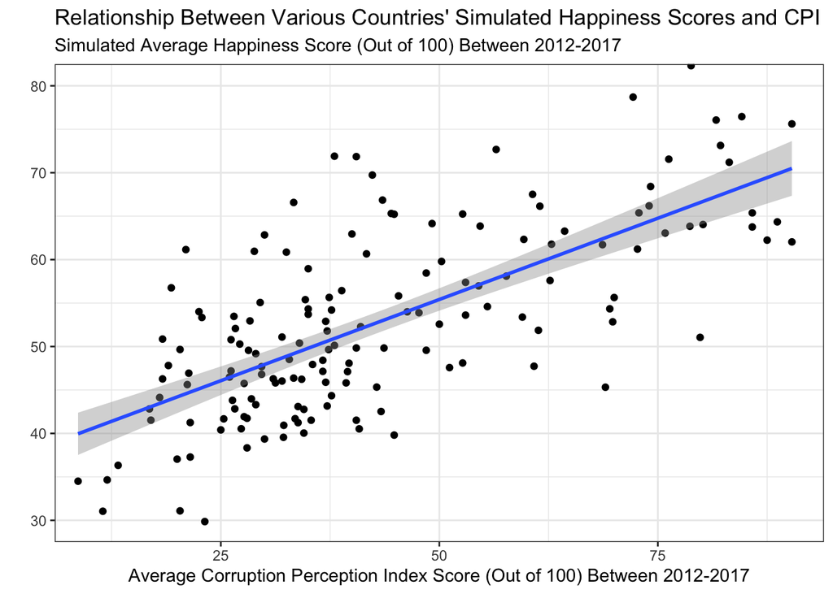

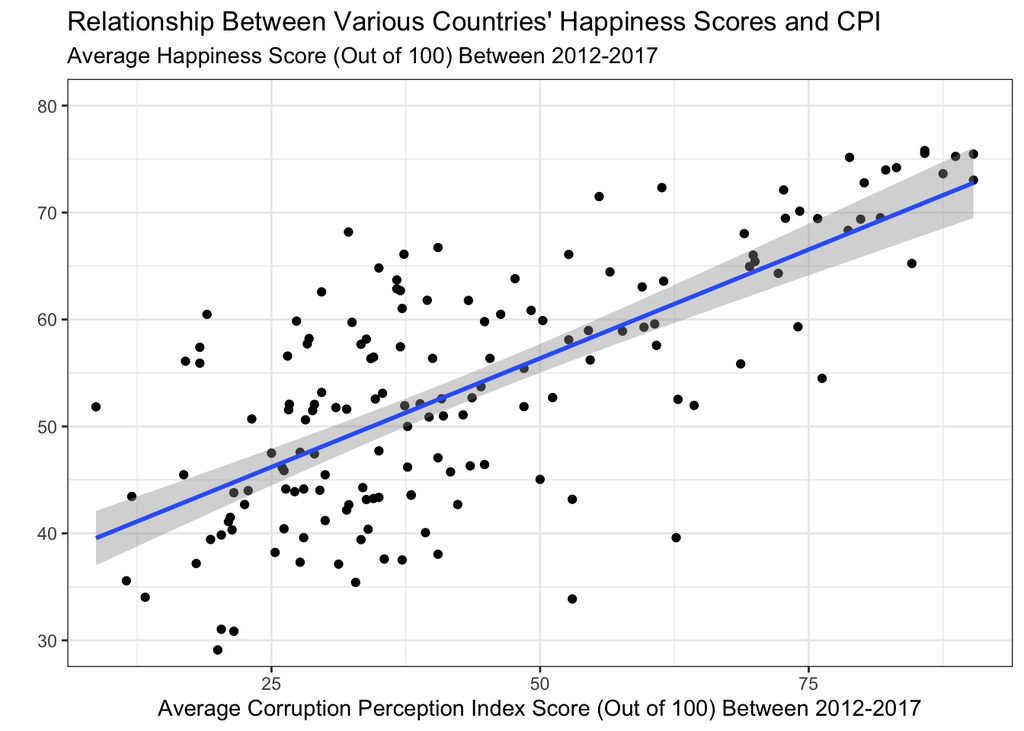

```r
ggplot(data = sim_data,
       mapping = aes(x = corruption,
                     y = sim_happiness)) +
  geom_point() +
  geom_smooth(method = "lm") +
  labs(title =
         "Relationship Between Various Countries' Simulated Happiness Scores and CPI",
       subtitle = "Simulated Average Happiness Score (Out of 100) Between 2012-2017",
       y = "",
       x = "Average Corruption Perception Index Score (Out of 100) Between 2012-2017") +
  coord_cartesian(xlim = c(10, 90), ylim = c(30, 80)) +
  theme_bw()
ggplot(data = data_by_country,
       mapping = aes(x = corruption,
                     y = happiness)) +
  geom_point() +
  geom_smooth(method = "lm") +
  labs(title =
         "Relationship Between Various Countries' Happiness Scores and CPI",
       subtitle = "Average Happiness Score (Out of 100) Between 2012-2017",
       y = "",
       x = "Average Corruption Perception Index Score (Out of 100) Between 2012-2017") +
  coord_cartesian(xlim = c(10, 90), ylim = c(30, 80)) +
  theme_bw()
```

From the side-by-side plots above, we can see that the simulated average happiness scores are reasonably similar to the observed average happiness scores, as both plots have a moderately strong, positive linear relationship. When studying the plots further, however, we noticed that the relationship with the simulated average happiness scores as the response seems to have a slightly flatter slope and a marginally higher intercept than the relationship with the observed average happiness scores. Depsite these minor differences, the variability in the plots seem relatively similar based on the visualization, and we feel confident about the similarities between the two plots.

## Generating Multiple Predictive Checks

To conduct predictive checks, we will generate 1,000 simulated datasets and regress each against our observed dataset. We will then keep the $R^2$ value from each regression and plot the distribution of the $R^2$ values from the regressions to further assess our model’s fit. If the $R^2$ values are distributed closer to 1, that would indicate good fit, however, if they are closer to 0, that would indicate that our model is not as good of a fit.

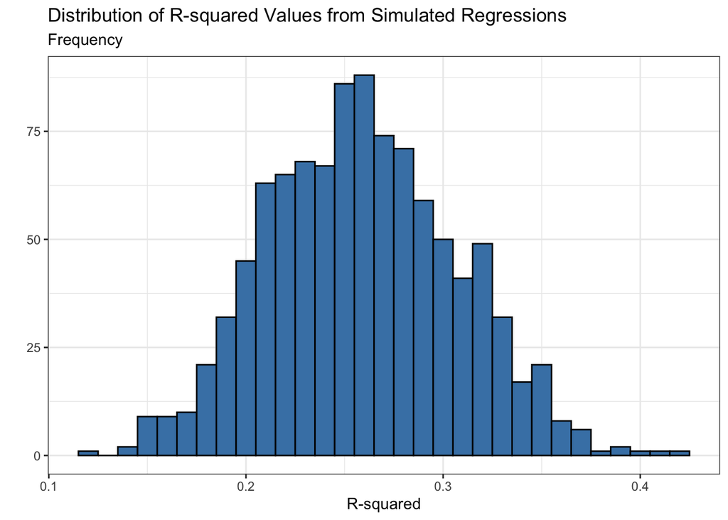

```r
fit_and_get_r_squared <- function(observed_data, observed_y, simulated_y) {

  combined_data <- data.frame(observed_y, simulated_y)

  combined_data <- na.omit(combined_data)

  simulated_model <- lm(observed_y ~ simulated_y, data = combined_data)

  return(summary(simulated_model)$r.squared)
}

simulate_r_squared <- function(observed_data, formula, n_simulations = 1000) {

  mod <- lm(formula, data = observed_data)

  simulated_responses <- map(1:n_simulations, ~ create_pred(mod))

  observed_y <- observed_data[[all.vars(formula)[1]]]

  r_squared_values <- map_dbl(simulated_responses, ~ fit_and_get_r_squared(observed_data, observed_y, .x))

  return(r_squared_values)
}

set.seed(123)

formula <- happiness ~ corruption

r_squared_values <- simulate_r_squared(data_by_country, formula, n_simulations = 1000)

r_squared_df <- data.frame(r_squared = r_squared_values)

ggplot(data = r_squared_df,
       aes(x = r_squared)) +
  geom_histogram(binwidth = 0.01, color = "black", fill = "steelblue") +
  labs(title = "Distribution of R-squared Values from Simulated Regressions",
       subtitle = "Frequency",
       x = "R-squared",
       y = "") +
  theme_bw()
```

Based on the distribution of the 1000 $R^2$ values for the relationship between the simulated and observed average happiness score above, we can conclude that our fitted model would not produce data that is very similar to our observed data since most of the $R^2$ values lie between 0.15 and 0.35. Running this simulation 1000 times means that we are examining numerous possible simulated models that our observed model could produce, and the highest $R^2$ values we attained are around 0.4, meaning only 40% of the variability in our observed happiness scores can be explained by the simulated happiness scores. Without a very strong $R^2$ between observed and simulated happiness scores, it’s more difficult to make conclusions based on this data. After conducting predictive checks, we are less confident on the strength of our model fit, however, we can still be assured that CPI score does partially explain some of the variability in the response and is a statistically significant predictor in average happiness score for a country.

# References

[Investopedia.com](https://www.investopedia.com/articles/investing/012215/how-corruption-affects-emerging-economies.asp)

[ChatGPT.com](https://chatgpt.com/)